# Grouped Summaries

# Goal

This notebook shows how to compare groups after deciding what summary each group should receive.

It adapts the aggregation and iteration ideas from the clinical PRAMS examples.

# Analytic Questions

We will ask:

- How does mean systolic blood pressure differ by adult age group?
- How do we separate the statistical summary from the visual display?
- How does a dot plot compare with a bar chart for group means?

# Load Data

```r
nhanes_path <- "data/real/nhanes_2021_2023_analysis.csv"

nhanes <- read_csv(nhanes_path, show_col_types = FALSE)
```

# Prepare Data

```r
adult_bp <- nhanes |>
  filter(
    age_years >= 18,
    !is.na(age_group),
    !is.na(systolic_mean)
  )

bp_by_age <- adult_bp |>
  group_by(age_group) |>
  summarise(
    n = n(),
    mean_systolic = mean(systolic_mean),
    median_systolic = median(systolic_mean),
    sd_systolic = sd(systolic_mean),
    se_systolic = sd_systolic / sqrt(n),
    lower = mean_systolic - 1.96 * se_systolic,
    upper = mean_systolic + 1.96 * se_systolic,
    .groups = "drop"
  ) |>
  mutate(age_group = reorder(age_group, mean_systolic))

bp_by_age
```

```
# A tibble: 5 × 8
  age_group     n mean_systolic median_systolic sd_systolic se_systolic lower
  <fct>     <int>         <dbl>           <dbl>       <dbl>       <dbl> <dbl>
1 18-29       882          112.            111         11.5       0.387  111.
2 30-44      1298          115.            114.        13.0       0.361  114.
3 45-64      2005          124.            123.        17.1       0.381  124.
4 65-79      1618          129.            127         19.3       0.480  128.
5 80+         320          135.            134         22.0       1.23   133.
# ℹ 1 more variable: upper <dbl>
```

# First Plot: Bars

Bars can show group means, but they can make a mean look like an amount that starts at zero.

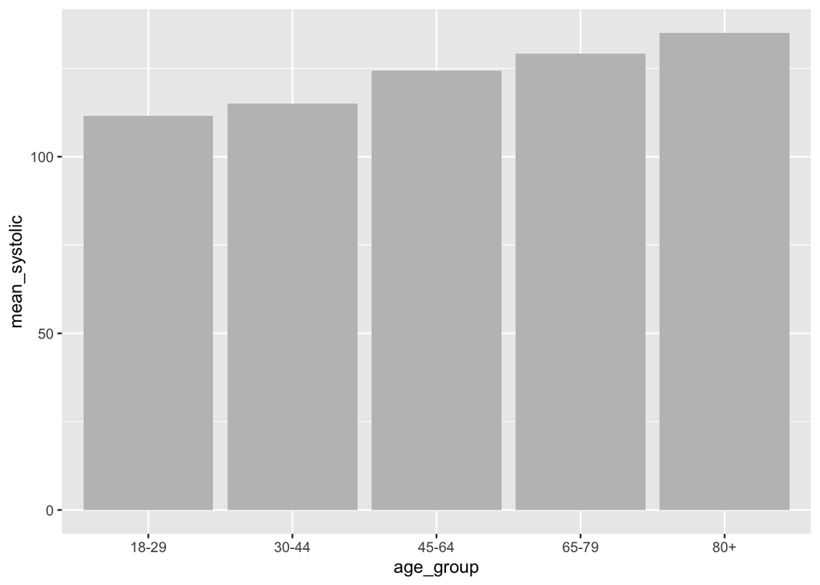

```r
p1 <- ggplot(bp_by_age, aes(x = age_group, y = mean_systolic)) +
  geom_col(fill = "gray75")

p1
```

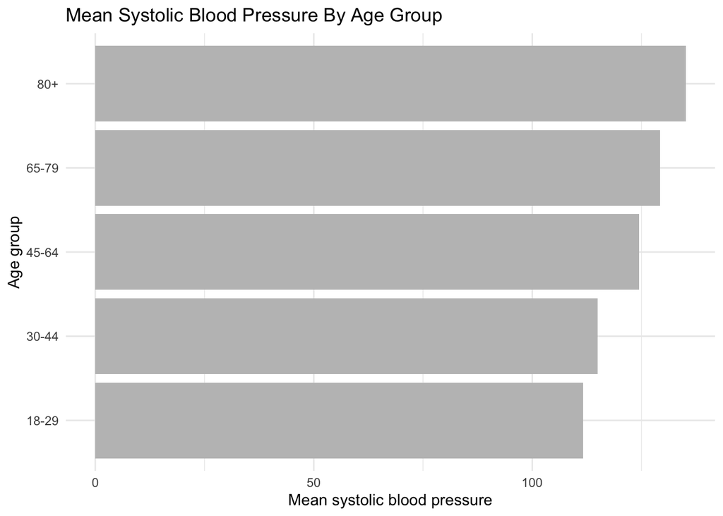

```r
p2 <- p1 +
  coord_flip() +
  labs(
    title = "Mean Systolic Blood Pressure By Age Group",
    x = "Age group",
    y = "Mean systolic blood pressure"
  ) +
  theme_minimal()

p2
```

# Dot Plot With Intervals

For group means, points and intervals often focus attention on comparisons between groups.

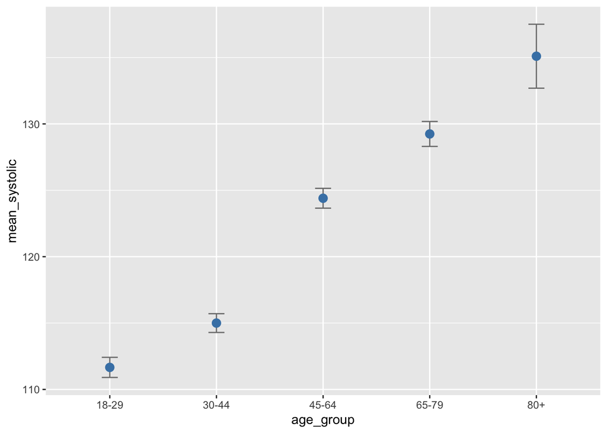

```r
p1 <- ggplot(bp_by_age, aes(x = age_group, y = mean_systolic)) +
  geom_errorbar(aes(ymin = lower, ymax = upper), width = 0.15, color = "gray50") +
  geom_point(size = 3, color = "steelblue")

p1
```

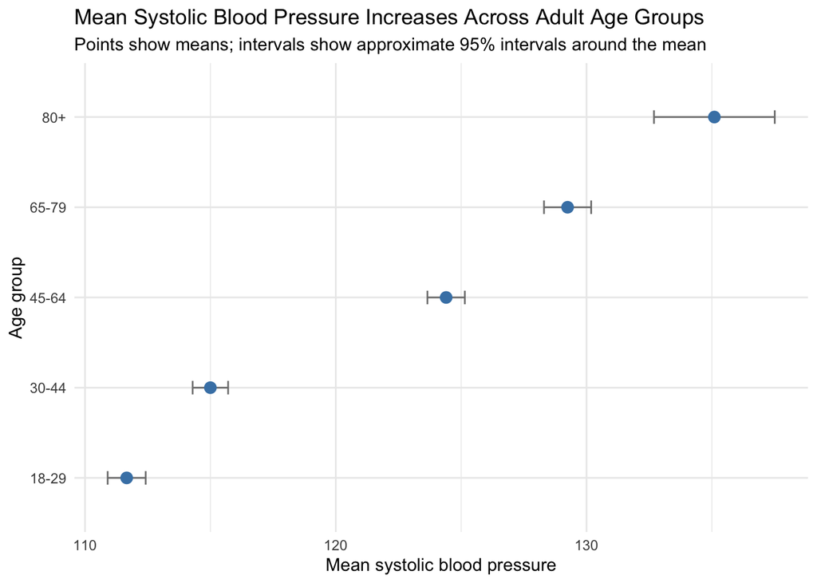

```r
p2 <- p1 +
  coord_flip() +
  labs(
    title = "Mean Systolic Blood Pressure Increases Across Adult Age Groups",
    subtitle = "Points show means; intervals show approximate 95% intervals around the mean",
    x = "Age group",
    y = "Mean systolic blood pressure"
  ) +
  theme_minimal()

p2
```

Interpretation: older age groups have higher mean systolic blood pressure in this sample. The intervals summarize uncertainty around each group mean, not the full spread of individual blood pressure values.

# Check The Distribution Behind The Summary

Group means should not replace a distribution check.

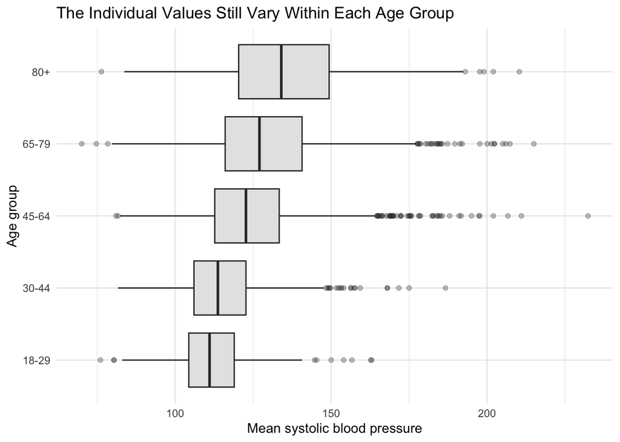

```r
p1 <- ggplot(adult_bp, aes(x = age_group, y = systolic_mean)) +
  geom_boxplot(fill = "gray90", outlier.alpha = 0.3)

p2 <- p1 +
  coord_flip() +
  labs(
    title = "The Individual Values Still Vary Within Each Age Group",
    x = "Age group",
    y = "Mean systolic blood pressure"
  ) +
  theme_minimal()

p2
```

# Takeaways

- Decide what one plotted row should represent before plotting.
- Manual summaries make the statistical step visible.
- Dot-and-interval plots are often clearer than bars for comparing group means.
- Summary plots should be checked against the distributions behind them.